# Investigating the Colleges and Universities Data Set

The Colleges and Universities data can be found here: https://hifld-geoplatform.opendata.arcgis.com/datasets/colleges-and-universities

### Overview of Contents:

1. Exploratory Data Analysis
2. Choosing the Question to Answer
3. Principal Component Analysis
4. Summary of Insights & the Data Driven Story

```python
# Import necessary libraries
%matplotlib inline
import matplotlib.pyplot as plt
import pandas as pd
import numpy as np
import seaborn as sns
from scipy import stats
from sklearn import preprocessing
from sklearn.decomposition import PCA

# Silence warnings for presentation format
import warnings
warnings.filterwarnings("ignore")
```

## 1. Exploratory Data Analysis

```python
# Read in the data and peek at the begining of the data set
data = pd.read_csv('Colleges_and_Universities.csv')
data.head()
```

|  | X | Y | OBJECTID | IPEDSID | NAME | ADDRESS | CITY | STATE | ZIP | ZIP4 | ... | ALIAS | SIZE_SET | INST_SIZE | PT_ENROLL | FT_ENROLL | TOT_ENROLL | HOUSING | DORM_CAP | TOT_EMP | SHELTER_ID |
| --- | --- | --- | --- | --- | --- | --- | --- | --- | --- | --- | --- | --- | --- | --- | --- | --- | --- | --- | --- | --- | --- |
| 0 | -79.954105 | 40.442599 | 1001 | 215293 | UNIVERSITY OF PITTSBURGH-PITTSBURGH CAMPUS | 4200 FIFTH AVENUE | PITTSBURGH | PA | 15260 | NOT AVAILABLE | ... | NOT AVAILABLE | 16 | 5 | 3060 | 25604 | 28664 | 1 | 7916 | 12602 | NOT AVAILABLE |
| 1 | -80.320347 | 40.754161 | 1002 | 215336 | BEAVER FALLS BEAUTY ACADEMY | 720 13TH ST | BEAVER FALLS | PA | 15010 | 4208 | ... | NOT AVAILABLE | -2 | 1 | -999 | 38 | 38 | 2 | -999 | 6 | NOT AVAILABLE |
| 2 | -97.103796 | 32.762234 | 1003 | 441742 | CONCORDE CAREER COLLEGE-GRAND PRAIRIE | 305 W. INTERSTATE 20 | GRAND PRAIRIE | TX | 75052 | 3831 | ... | NOT AVAILABLE | 2 | 1 | -999 | 811 | 811 | 2 | -999 | 88 | NOT AVAILABLE |
| 3 | -94.077126 | 30.047885 | 1004 | 441760 | LAMAR INSTITUTE OF TECHNOLOGY | 855 E LAVACA | BEAUMONT | TX | 77705 | NOT AVAILABLE | ... | NOT AVAILABLE | 2 | 2 | 1620 | 1248 | 2868 | 2 | -999 | 263 | NOT AVAILABLE |
| 4 | -80.001462 | 40.438526 | 1005 | 215442 | POINT PARK UNIVERSITY | 201 WOOD ST | PITTSBURGH | PA | 15222 | 1984 | ... | NOT AVAILABLE | 13 | 2 | 1150 | 2943 | 4093 | 1 | 1070 | 1128 | NOT AVAILABLE |

5 rows × 45 columns

```python
# Look at the variables with object data types
data.dtypes[data.dtypes == 'object']
```

```
NAME          object
ADDRESS       object
CITY          object
STATE         object
ZIP4          object
TELEPHONE     object
STATUS        object
COUNTY        object
COUNTYFIPS    object
COUNTRY       object
NAICS_DESC    object
SOURCE        object
SOURCEDATE    object
VAL_METHOD    object
VAL_DATE      object
WEBSITE       object
STFIPS        object
COFIPS        object
CLOSE_DATE    object
ALIAS         object
SHELTER_ID    object
dtype: object
```

```python
# Look at the variables with numeric data types
data.dtypes[data.dtypes != 'object']
```

```
X             float64
Y             float64
OBJECTID        int64
IPEDSID         int64
ZIP             int64
TYPE            int64
POPULATION      int64
LATITUDE      float64
LONGITUDE     float64
NAICS_CODE      int64
SECTOR          int64
LEVEL_          int64
HI_OFFER        int64
DEG_GRANT       int64
LOCALE          int64
MERGE_ID        int64
SIZE_SET        int64
INST_SIZE       int64
PT_ENROLL       int64
FT_ENROLL       int64
TOT_ENROLL      int64
HOUSING         int64
DORM_CAP        int64
TOT_EMP         int64
dtype: object
```

```python
'''
Count NULL values in this data set.
Empty list means there are no NULL values in the data set.
'''

count_nulls = {}
for column in data.columns:
    null_pct = {column : len(data[column].isnull())/data.shape[0]}
    count_nulls.update(null_pct)
print([x for x in count_nulls.keys() if count_nulls[x] == 0])
```

```
[]
```

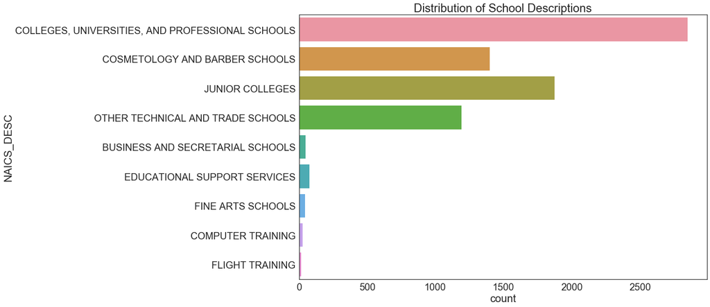

```python
# Look at the distribution of NAICS school descriptions
sns.set(style="white", font_scale=2)
f, ax = plt.subplots(figsize=(15, 10))
plt.title('Distribution of School Descriptions')
sns.countplot(y='NAICS_DESC', data=data)
```

**Most Common:** Colleges, universities, and professional schools  
**Second Most Common:** Junior colleges

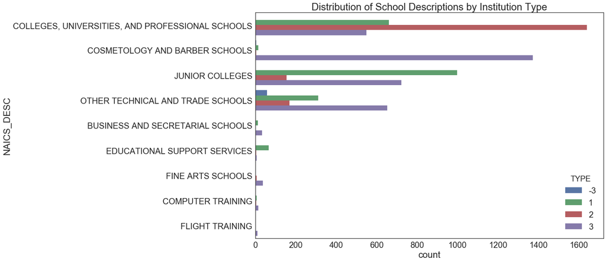

```python
# Look at the distribution of NAICS school descriptions
sns.set(style="white", font_scale=2)
f, ax = plt.subplots(figsize=(15, 10))
plt.title('Distribution of School Descriptions by Institution Type')
sns.countplot(y='NAICS_DESC', hue='TYPE', data=data)
```

Observations:

- Most colleges, universities, and professional schools are of Insitution Type 2.
- Most junior colleges are Institution Type 1.

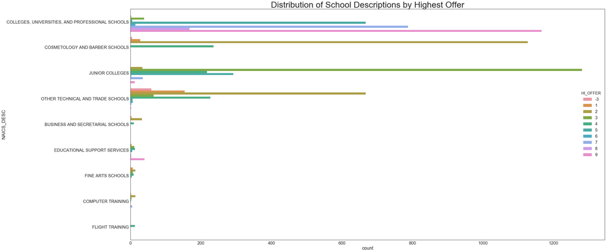

```python
# Look at the distribution of NAICS school descriptions
sns.set(style="white", font_scale=2)
f, ax = plt.subplots(figsize=(40, 20))
plt.title('Distribution of School Descriptions by Highest Offer', fontsize=40)
sns.countplot(y='NAICS_DESC', hue='HI_OFFER', data=data)
```

Schools with mostly higher highest offer:

- Colleges, universities, and professional schools
- Educational support services

Schools with mostly lower highest offer:

- Junior colleges and technical trade
- Business and secretarial schools
- Fine arts schools
- Computer training

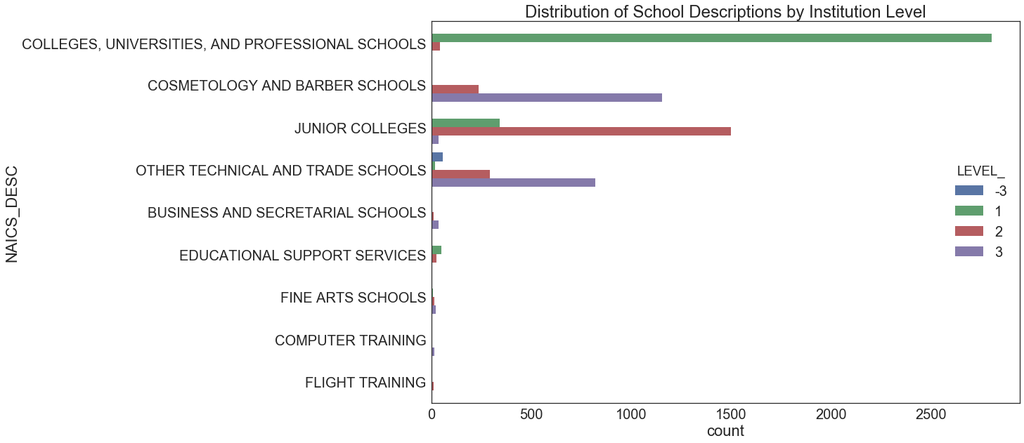

```python
# Look at the distribution of NAICS school descriptions
sns.set(style="white", font_scale=2)
f, ax = plt.subplots(figsize=(15, 10))
plt.title('Distribution of School Descriptions by Institution Level')
sns.countplot(y='NAICS_DESC', hue='LEVEL_', data=data)
```

Schools that are mostly level 1 institutions:

- Colleges, universities, and professional schools

Schools that are mostly level 2 institutions:

- Cosmetology and barber schools
- Other technical and trade schools
- Business and secretarial schools
- Fine arts schools
- Computer Training

#### What are "X" and "Y"?

Comparing X and Y to longitude and latitude shows that X is longitude and Y is latitude.

```python
# The output below shows that the X is approximately Longitude and Y is approximately Latitude
print(np.unique(np.round(data.X.astype(str).astype(float),2) == np.round(data.LONGITUDE,2)))
print(np.unique(np.round(data.Y.astype(str).astype(float),2) == np.round(data.LATITUDE,2)))
```

```
[ True]
[ True]
```

#### What is the "Population" variable?

Population numbers are derived by adding Total Employees and Total Enrollment together, where -999 values are most likely missing values.

```python
# The output below shows that the population is equal to the sum of the total enrolled and the total employees
df_pop = data[['POPULATION', 'TOT_ENROLL','TOT_EMP']].replace(-999, 0)
print(np.unique(df_pop.POPULATION == df_pop.TOT_ENROLL + df_pop.TOT_EMP))
```

```
[ True]
```

```python
# Get descriptive statistics of the numerical features
data[data.dtypes[data.dtypes != 'object'].drop(['X','Y','LATITUDE','LONGITUDE','ZIP', 'OBJECTID', 'IPEDSID', 'MERGE_ID', 'NAICS_CODE']).index].describe()
```

|  | TYPE | POPULATION | SECTOR | LEVEL_ | HI_OFFER | DEG_GRANT | LOCALE | SIZE_SET | INST_SIZE | PT_ENROLL | FT_ENROLL | TOT_ENROLL | HOUSING | DORM_CAP | TOT_EMP |
| --- | --- | --- | --- | --- | --- | --- | --- | --- | --- | --- | --- | --- | --- | --- | --- |
| count | 7520.000000 | 7520.000000 | 7520.000000 | 7520.000000 | 7520.000000 | 7520.000000 | 7520.000000 | 7520.000000 | 7520.000000 | 7520.000000 | 7520.000000 | 7520.000000 | 7520.000000 | 7520.000000 | 7520.000000 |
| mean | 2.133378 | 3134.994415 | 5.499069 | 1.806516 | 4.542686 | 1.310239 | 19.534441 | 3.894415 | 1.539894 | 707.809574 | 1581.393351 | 2636.196011 | 1.504255 | -289.844149 | 401.156782 |
| std | 0.960396 | 7912.557004 | 9.135399 | 0.939271 | 2.667660 | 0.619883 | 9.362532 | 6.213390 | 1.116682 | 3274.577476 | 4692.926607 | 6718.699885 | 0.841460 | 1583.284973 | 1577.565295 |
| min | -3.000000 | -999.000000 | 0.000000 | -3.000000 | -3.000000 | -3.000000 | -3.000000 | -2.000000 | -2.000000 | -999.000000 | -999.000000 | -999.000000 | -2.000000 | -999.000000 | -999.000000 |
| 25% | 1.000000 | 98.000000 | 2.000000 | 1.000000 | 2.000000 | 1.000000 | 12.000000 | -2.000000 | 1.000000 | -999.000000 | 53.000000 | 76.000000 | 1.000000 | -999.000000 | 15.000000 |
| 50% | 2.000000 | 380.500000 | 4.000000 | 2.000000 | 4.000000 | 1.000000 | 21.000000 | 2.000000 | 1.000000 | 42.000000 | 230.000000 | 314.000000 | 2.000000 | -999.000000 | 60.000000 |
| 75% | 3.000000 | 2616.500000 | 8.000000 | 3.000000 | 7.000000 | 2.000000 | 22.000000 | 8.000000 | 2.000000 | 592.250000 | 1305.250000 | 2144.500000 | 2.000000 | 121.000000 | 390.250000 |
| max | 3.000000 | 145005.000000 | 99.000000 | 3.000000 | 9.000000 | 2.000000 | 43.000000 | 18.000000 | 5.000000 | 61290.000000 | 131629.000000 | 131629.000000 | 2.000000 | 18824.000000 | 31367.000000 |

The data set appears to have missing values that were replaced with negative values. For example, the minimum number of students enrolled is -999 as seen in the descriptive statistics.

```python
'''
Numeric Value Counts in Original Data Set
'''
# Get value counts for each numerical feature
numerical_columns = data.dtypes[data.dtypes != 'object'].drop(['X','Y','LATITUDE','LONGITUDE','ZIP', 'OBJECTID', 'IPEDSID', 'MERGE_ID', 'NAICS_CODE']).index

# for col in numerical_columns:
#     print("---- %s ---" % col)
#     print(data[col].value_counts())
```

As with all data projects, a specific question needs to be asked in order to select a data strategy and solve the business problem. Now some exploratory data analysis has been conducted, a question can be formulated.

## 2. Choosing The Question to Answer

A common issue in education is having enough teachers, or staff, to accommodate the needs of each student. With the given data set, we can pose the following question:

## The Question: Which schools are most accommodating for students?

This question can be tackled by creating new metrics, using exploratory analysis, and implementing unsupervised learning methods.

```python
'''
Create a new dataframe
where number of full-time students enrolled and number of employees is greater than zero, or not missing.
'''
df = data[data.TOT_ENROLL > 0][data.TOT_EMP > 0]
print("There were {} schools dropped in the analysis.".format(data.shape[0] - df.shape[0]))
```

```
There were 735 schools dropped in the analysis.
```

### Create a new metric to measure level of accommodation

The ratio between total enrolled students and total employees will be the metric for calculating how accomodating a school is. A higher ratio would suggest that each employee has to accommodate more students on average, which means the school would be less able to accomodate every student's needs. The total enrollment feature was selected over the part-time or full-time enrollment feature to account for all students' needs.

```python
# Create a new feature to represent the student to employee ratio called RATIO
df['RATIO'] = df.TOT_ENROLL / df.TOT_EMP
```

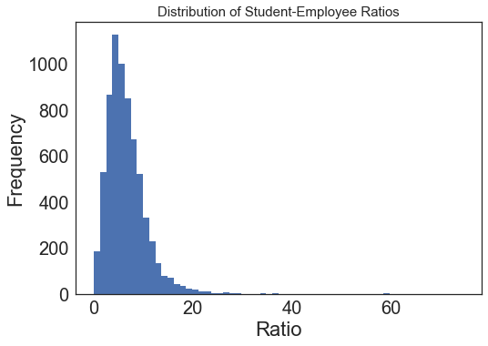

```python
# Look at the distribution of student to employee ratios
df.RATIO.plot(kind = 'hist', bins=60)
plt.title('Distribution of Student-Employee Ratios', fontsize=15)
plt.xlabel('Ratio')
```

```python
'''
Numeric Value Counts in Reduced Data Set
'''

# Get value counts for each numerical feature
numerical_columns = data.dtypes[data.dtypes != 'object'].drop(['X','Y','LATITUDE','LONGITUDE','ZIP', 'OBJECTID', 'IPEDSID', 'MERGE_ID', 'NAICS_CODE']).index

# for col in numerical_columns:
#     print("---- %s ---" % col)
#     print(df[col].value_counts())
```

### Binning the feature

Bin the student-employee ratio into intervals for plotting against ordinal variables.

```python
# Randomly chose to bin the ratio feature into 5 intervals
pd.qcut(df.RATIO, 5).value_counts()
```

```
(6.693, 9.125]      1359
(4.978, 6.693]      1357
(3.464, 4.978]      1357
(0.00726, 3.464]    1357
(9.125, 74.551]     1355
Name: RATIO, dtype: int64
```

```python
# Create a new feature in the dataset with new ratio intervals
df['ORDINAL_RATIO'] = pd.qcut(df.RATIO, 5, labels= False)
```

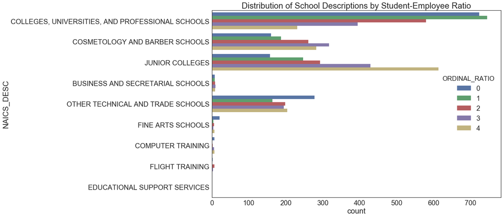

```python
# Look at the distribution of NAICS school descriptions against the student-employee ratio
sns.set(style="white", font_scale=2)
f, ax = plt.subplots(figsize=(15, 10))
plt.title('Distribution of School Descriptions by Student-Employee Ratio')
sns.countplot(y='NAICS_DESC', hue='ORDINAL_RATIO', data=df)
```

The above histogram shows:

- Most colleges, universities, and professional schools are accommodating.
- Most Junior Colleges, Cosmetology, Barber Schools, Business & Secretarial Schools, and Computer Training schools have high student-employee ratios, which makes them less accomodating.

```python
# Retrieve the numerical columns in the new dataframe, including RATIO
numerical_columns2 = df.dtypes[df.dtypes != 'object'].drop(['X','Y','LATITUDE','LONGITUDE','ZIP', 'OBJECTID', 'IPEDSID', 'MERGE_ID', 'NAICS_CODE']).index
```

### Pairwise Plot

It would be interesting to see the difference between the institution levels. Examining a pairwise plot colored by institution level can be used to gain a better understanding.

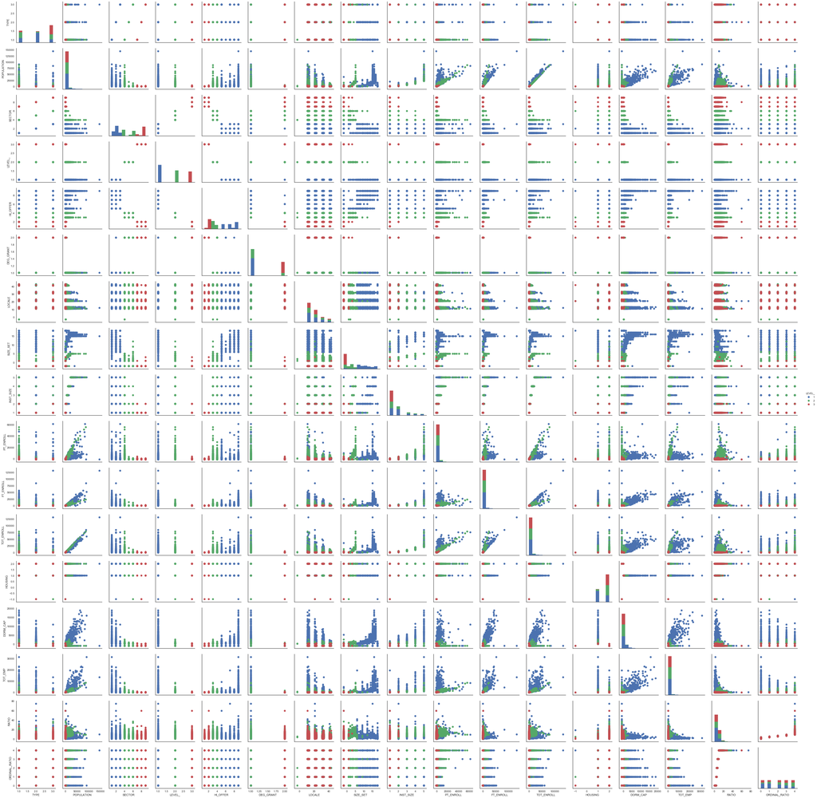

```python
# Set up pairwise plot
sns.set(style="white")
g = sns.PairGrid(df[numerical_columns2], hue='LEVEL_')
g.map_diag(plt.hist)
g.map_offdiag(plt.scatter)
g.add_legend()
```

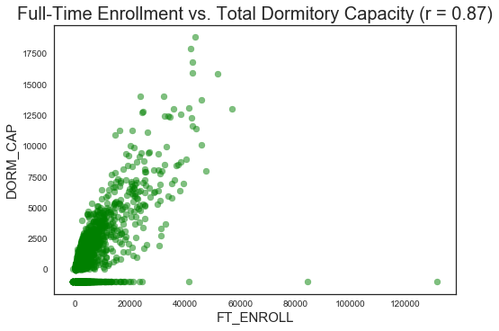

```python
'''
Correlation between Full-time Enrollment and Total Dormitory Capacity
'''
# Get the correlation matrix
corr_enroll_dorm = np.round(stats.pearsonr(df[df.DORM_CAP != -999].FT_ENROLL, df[df.DORM_CAP != -999].DORM_CAP)[0],2)
# Use the scatterplot to better understand the relationship
plt.figure('Total Dormitory Capacity vs. Full-Time Enrollment')
plt.scatter(df.FT_ENROLL, df.DORM_CAP, c = 'g', alpha=0.5)
plt.xlabel('FT_ENROLL',fontsize=15)
plt.ylabel('DORM_CAP', fontsize=15)
plt.title('Full-Time Enrollment vs. Total Dormitory Capacity (r = {})'.format(corr_enroll_dorm), fontsize = 20)
```

Some information we gain from looking at the pairwise plot and correlation coefficient values:

- There is a very strong positive linear relationship between the number of full-time enrolled students (**FT_ENROLL**) and total dormitory capacity (**DORM_CAP**) due to the high correlation coefficient value denoted as "r".
- Schools with higher enrollment or higher total employees tend to be level 1 and 2 schools.
- Schools with higher total dormitory capacity tend to be level 1 schools.

### Understanding the Ordinal Features

Since the ordinal features have several anomalies where the values are negative, I decided to see if there was a difference in the correlation between these features.

```python
# Select the features that are ordinal
ordinal_features = ['TYPE','SECTOR','LEVEL_','HI_OFFER','LOCALE','SIZE_SET','INST_SIZE']
# Subset the data on the ordinal features
ordinal_df = df[ordinal_features]
# Replace the negative values with NULL for easier removal using dropna function
ordinal_df[ordinal_df < 0] = np.nan
print("There were {} schools dropped in the analysis due to negative values.".format(ordinal_df.shape[0] - ordinal_df.dropna().shape[0]))
```

```
There were 2534 schools dropped in the analysis due to negative values.
```

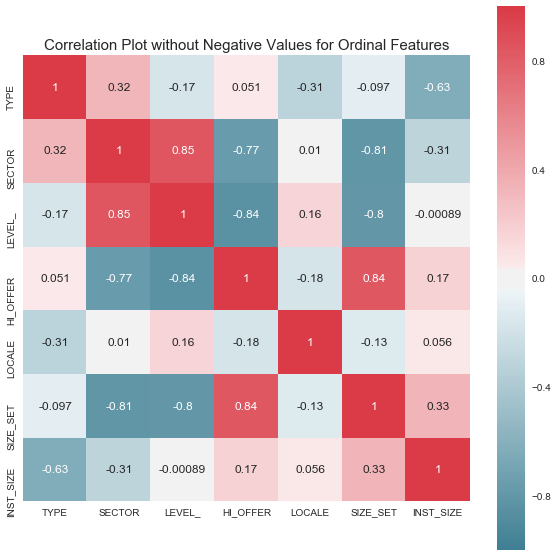

```python
# Use Spearman rank correlation for ordinal features
sns.set(style= 'white', font_scale=1)
# Get the correlation matrix
corr_ordinal = ordinal_df.dropna().corr(method='spearman')
# Plot the correlation matrix on a heatmap
f, ax = plt.subplots(figsize=(10, 10))
plt.title('Correlation Plot without Negative Values for Ordinal Features', fontsize = 15)
sns.heatmap(corr_ordinal, annot= True, mask=np.zeros_like(corr_ordinal, dtype=np.bool), cmap=sns.diverging_palette(220, 10, as_cmap=True),
            square=True, ax=ax)
```

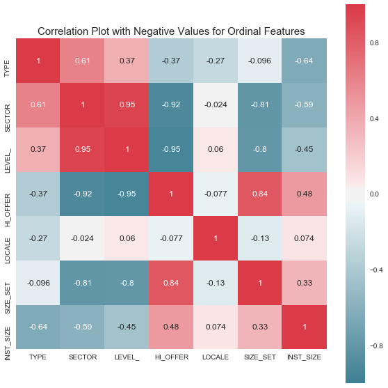

```python
# Use Spearman rank correlation for ordinal features
sns.set(style= 'white', font_scale=1)
# Get the correlation matrix
corr_ordinal2 = ordinal_df[ordinal_features].corr(method='spearman')
# Plot the correlation matrix on a heatmap
f, ax = plt.subplots(figsize=(10, 10))
plt.title('Correlation Plot with Negative Values for Ordinal Features', fontsize = 15)
sns.heatmap(corr_ordinal2, annot= True, mask=np.zeros_like(corr_ordinal2, dtype=np.bool), cmap=sns.diverging_palette(220, 10, as_cmap=True),
            square=True, ax=ax)
```

**Strong positive linear relationship:**

- LEVEL & SECTOR
- SIZE SET & HI OFFER

**Strong negative linear relationship:**

- HI OFFER & SECTOR
- HI OFFER & LEVEL
- SIZE SET & SECTOR
- SIZE SET & LEVEL

# 3. Principal Component Analysis

To implement PCA on the data, we first need to normalize the data and scale to unit variance. It is also important to not include features that are linear combinations of other features, which are Population and Total Enrollment in this case.

```python
'''
Normalize data for PCA
'''
# Normalize data and drop features that are linear combinations of other features
X = preprocessing.StandardScaler().fit_transform(df[numerical_columns].drop(['POPULATION','TOT_ENROLL'], axis=1))
```

```python
# Initiate with a large number of components
pca = PCA(n_components=11)
# Get the project PCA scores
projected = pca.fit_transform(X)
```

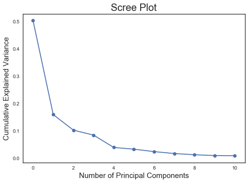

```python
plt.plot(pca.explained_variance_ratio_, marker='o')
plt.title('Scree Plot', fontsize=20)
plt.xlabel('Number of Principal Components', fontsize=15)
plt.ylabel('Cumulative Explained Variance', fontsize=15)
plt.show()
```

The number of principal components to use is determined at the point beyond which the additional explained variance are all relatively small and of comparable size. In the scree plot, this number of principal components to use corresponds to 4. Therefore, **four principal components** will be used in the analysis.

```python
# Refit PCA on 4 principal components and create dataframe for biplot
reduced_data = PCA(n_components=4).fit_transform(X)
reduced_data = pd.DataFrame(reduced_data, columns = ['PC 1', 'PC 2', 'PC 3', 'PC 4'])
```

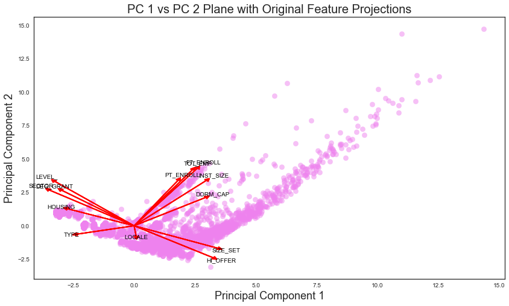

```python
'''
Biplot function
'''
def biplot(data, reduced_data, pca):

    fig, ax = plt.subplots(figsize = (14,8))

    # Scatterplot of the reduced data
    ax.scatter(x=reduced_data.loc[:, 'PC 1'], y=reduced_data.loc[:, 'PC 2'], facecolors='violet', edgecolors='violet', s=70, alpha=0.5)

    feature_vectors = pca.components_.T

    # Use scaling factors to make the arrows
    arrow_size, text_pos = 10.0, 11.0

    # Projections of the original features
    for i, v in enumerate(feature_vectors):
        ax.arrow(0, 0, arrow_size*v[0], arrow_size*v[1], head_width=0.2, head_length=0.2, linewidth=2, color='red')
        ax.text(v[0]*text_pos, v[1]*text_pos, df[numerical_columns].drop(['POPULATION','TOT_ENROLL'], axis=1).columns[i], color='black', ha='center', va='center', fontsize=10)

    ax.set_xlabel("Principal Component 1", fontsize=18)
    ax.set_ylabel("Principal Component 2", fontsize=18)
    ax.set_title("PC 1 vs PC 2 Plane with Original Feature Projections", fontsize=20);
    return ax

biplot(df, reduced_data, pca)
```

```python
'''
Principal Components Table
'''
# Create a table showing the principal component vectors and corresponding feature labels
pd.DataFrame({'Features': df[numerical_columns].drop(['POPULATION','TOT_ENROLL'], axis=1).columns,'PC 1 ({}%)'.format(np.round(pca.explained_variance_ratio_[0]*100)):pca.components_[0], 'PC 2 ({}%)'.format(np.round(pca.explained_variance_ratio_[1]*100)): pca.components_[1], 'PC 3 ({}%)'.format(np.round(pca.explained_variance_ratio_[2]*100)): pca.components_[2], 'PC 4 ({}%)'.format(np.round(pca.explained_variance_ratio_[3]*100)): pca.components_[3]})
```

|  | Features | PC 1 (50.0%) | PC 2 (16.0%) | PC 3 (10.0%) | PC 4 (8.0%) |
| --- | --- | --- | --- | --- | --- |
| 0 | TYPE | -0.234164 | -0.062667 | 0.539356 | 0.010853 |
| 1 | SECTOR | -0.347856 | 0.267282 | 0.087144 | -0.105051 |
| 2 | LEVEL_ | -0.325528 | 0.332248 | -0.081175 | -0.125922 |
| 3 | HI_OFFER | 0.324993 | -0.239355 | 0.206651 | 0.010277 |
| 4 | DEG_GRANT | -0.296983 | 0.265528 | 0.100364 | -0.237410 |
| 5 | LOCALE | 0.008853 | -0.079813 | -0.645900 | -0.501387 |
| 6 | SIZE_SET | 0.343882 | -0.167819 | 0.119801 | 0.032377 |
| 7 | INST_SIZE | 0.296756 | 0.339100 | -0.159989 | 0.174659 |
| 8 | PT_ENROLL | 0.181074 | 0.340853 | -0.286250 | 0.489549 |
| 9 | FT_ENROLL | 0.259096 | 0.429026 | 0.144680 | -0.087119 |
| 10 | HOUSING | -0.272703 | 0.127166 | -0.043901 | 0.433521 |
| 11 | DORM_CAP | 0.293459 | 0.211637 | 0.209646 | -0.427950 |
| 12 | TOT_EMP | 0.239947 | 0.419191 | 0.190389 | -0.123483 |

Interpretation of principal components is based on finding which features are most strongly correlated with each component, i.e., which of these numbers are large in magnitude, the farthest from zero in either direction.

Based on the principal components table and biplot, the following interpretation can be made:  
**Principal Component 1** (PC 1) represents approximately 50% of the variation in the data set. The higher positive PC 1 scores represent higher values in HI OFFER and SIZE SET. The negative PC 1 scores represent lower values in SECTOR and LEVEL.

This suggests that schools with high PC 1 scores have higher highest offers and Carnegie Classification numbers with relatively lower institution sector numbers, and institution level numbers.

**Principal Component 2** (PC 2) represents approximately 16% of the variation in the data set. The positive scores represents FT ENROLL and TOT_EMP. The negative scores represent higher values in HI OFFER.

This suggests that schools with high PC 2 scores have relatively higher full-time enrollment and total employees with relatively lower highest offer.

PC 1 and 2 represent the most variation in the data, so the interpretation of PC 1 and 2 will be the main takeaways from this PCA.

*Additional interpretation of other principal components:*

Principal Component 3 (PC 3) represents approximately 10% of the variation in the data set. The positive scores represents TYPE. The negative scores represent higher values in LOCALE.

This suggests that schools with high PC 3 scores have higher institution type numbers with relatively lower degree of urbanization.

Principal Component 4 (PC 4) represents approximately 8% of the variation in the data set. The positive scores represents PT ENROLL. The negative scores represent higher values in LOCALE.

This suggests that schools with high PC 4 scores have higher part-time enrollment with relatively lower values in degree of urbanization.

## Score Plots Colored by Important Features

From the PCA implementation, the important features are represented by highest offer, Carnegie Classification, Institution Sector, and Institution level.

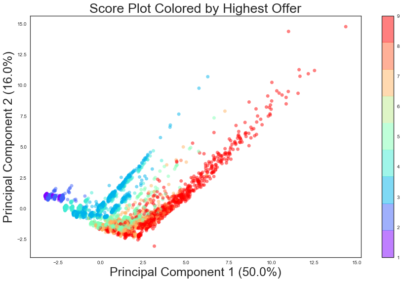

```python
'''
Create a Score Plot showing difference in Highest Offer
'''
# Set up the matplotlib fig
f, ax = plt.subplots(figsize=(15, 9))
# Plot projected PCA scores colored by degree-granting status
plt.scatter(projected[:, 0], projected[:, 1],
            c=df.HI_OFFER, edgecolor='none', alpha=0.5, cmap=plt.cm.get_cmap('rainbow', 9))
plt.title('Score Plot Colored by Highest Offer', fontsize=27)
plt.xlabel('Principal Component 1 ({}%)'.format(np.round(pca.explained_variance_ratio_[0]*100)), fontsize=25)
plt.ylabel('Principal Component 2 ({}%)'.format(np.round(pca.explained_variance_ratio_[1]*100)), fontsize=25)
plt.colorbar()
```

This score plot confirms the interpretation made for PC 1 by showing that the lower PC 1 scores are represented by the lower highest offer and the higher scores are represented by higher highest offer (increasing left to right).

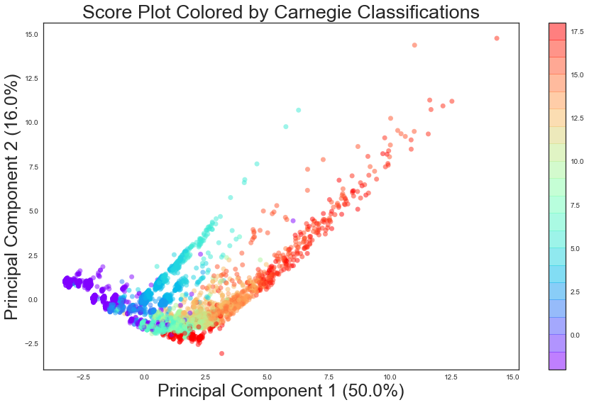

```python
'''
Create a Score Plot showing difference in Carnegie Classifications
'''
# Set up the matplotlib fig
f, ax = plt.subplots(figsize=(15, 9))
# Plot projected PCA scores colored by degree-granting status
plt.scatter(projected[:, 0], projected[:, 1],
            c=df.SIZE_SET, edgecolor='none', alpha=0.5, cmap=plt.cm.get_cmap('rainbow', 20))
plt.title('Score Plot Colored by Carnegie Classifications', fontsize=27)
plt.xlabel('Principal Component 1 ({}%)'.format(np.round(pca.explained_variance_ratio_[0]*100)), fontsize=25)
plt.ylabel('Principal Component 2 ({}%)'.format(np.round(pca.explained_variance_ratio_[1]*100)), fontsize=25)
plt.colorbar()
```

This score plot confirms the interpretation made for PC 1 by showing that the lower PC 1 scores are represented by the lower Carnegie Classification and the higher scores are represented by higher Carnegie Classification (increasing left to right).

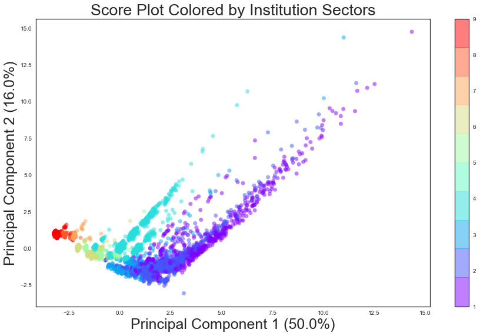

```python
'''
Create a Score Plot showing difference in Institution Sectors
'''
# Set up the matplotlib fig
f, ax = plt.subplots(figsize=(15, 9))
# Plot projected PCA scores colored by degree-granting status
plt.scatter(projected[:, 0], projected[:, 1],
            c=df.SECTOR, edgecolor='none', alpha=0.5, cmap=plt.cm.get_cmap('rainbow', 10))
plt.title('Score Plot Colored by Institution Sectors', fontsize=27)
plt.xlabel('Principal Component 1 ({}%)'.format(np.round(pca.explained_variance_ratio_[0]*100)), fontsize=25)
plt.ylabel('Principal Component 2 ({}%)'.format(np.round(pca.explained_variance_ratio_[1]*100)), fontsize=25)
plt.colorbar()
```

This score plot confirms the interpretation made for PC 1 by showing that the lower PC 1 scores are represented by the higher institution sector and the higher scores are represented by lower institution sector (decreasing left to right).

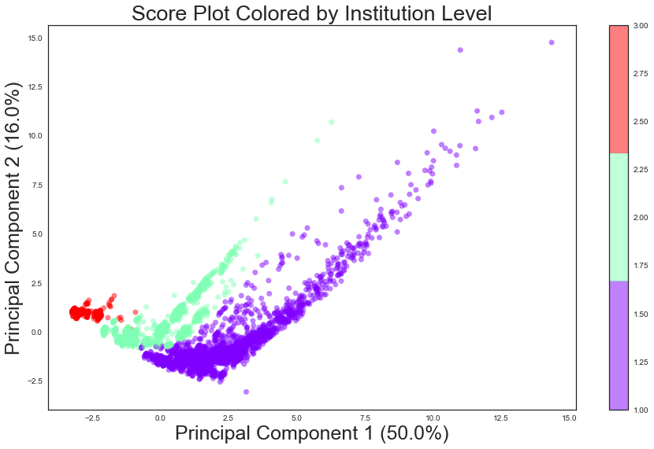

```python
'''
Create a Score Plot showing difference in Institution Level
'''
# Set up the matplotlib fig
f, ax = plt.subplots(figsize=(15, 9))
# Plot projected PCA scores colored by degree-granting status
plt.scatter(projected[:, 0], projected[:, 1],
            c=df.LEVEL_, edgecolor='none', alpha=0.5, cmap=plt.cm.get_cmap('rainbow', 3))
plt.title('Score Plot Colored by Institution Level', fontsize=27)
plt.xlabel('Principal Component 1 ({}%)'.format(np.round(pca.explained_variance_ratio_[0]*100)), fontsize=25)
plt.ylabel('Principal Component 2 ({}%)'.format(np.round(pca.explained_variance_ratio_[1]*100)), fontsize=25)
plt.colorbar()
```

This score plot confirms the interpretation made for PC 1 by showing that the lower PC 1 scores are represented by the higher institution level and the higher scores are represented by lower institution level (decreasing left to right).

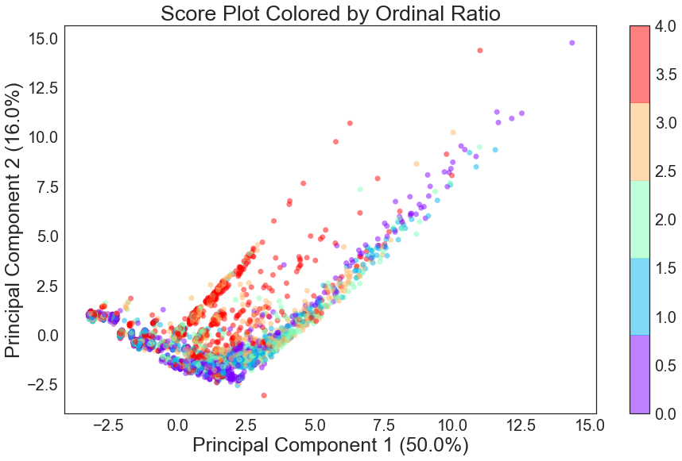

```python
'''
Create a Score Plot showing difference in Student-Employee Ratio
'''
# Set up the matplotlib fig
f, ax = plt.subplots(figsize=(15, 9))
# Plot projected PCA scores colored by degree-granting status
plt.scatter(projected[:, 0], projected[:, 1],
            c=df.ORDINAL_RATIO, edgecolor='none', alpha=0.5, cmap=plt.cm.get_cmap('rainbow', 5))
plt.title('Score Plot Colored by Ordinal Ratio', fontsize=27)
plt.xlabel('Principal Component 1 ({}%)'.format(np.round(pca.explained_variance_ratio_[0]*100)), fontsize=25)
plt.ylabel('Principal Component 2 ({}%)'.format(np.round(pca.explained_variance_ratio_[1]*100)), fontsize=25)
plt.colorbar()
```

This score plot colored by the student-employee ratio shows that there are more purple, blue, and green dots than red and orange dots towards the right side, which suggests that lower student-employee ratios exist to the right of the plot. Comparing this score plot colored by student-employee ratio to the other score plots, there exists a visual trend that lower student employee ratios have higher highest offers, higher Carnegie Classifications, lower institution sector numbers and lower institution level numbers. This may be a bit subjective so it would be a good idea to take a closer look at the differences through histograms.

## Comparing the Important Features to the Student-Employee Ratio Further through Histograms

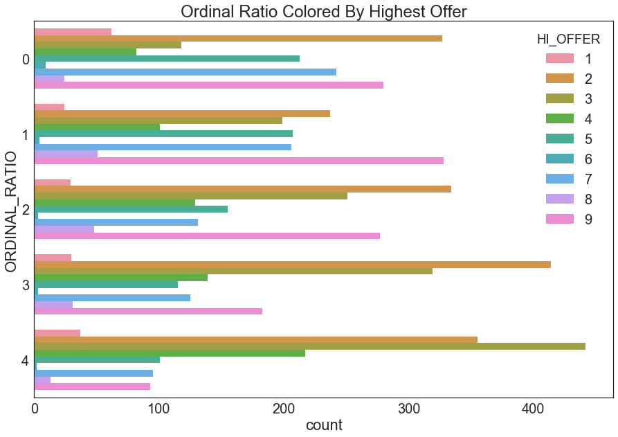

```python
'''
Plot Student-Employee Ratio Colored by Highest Offer
'''
# Look at the distribution of NAICS school descriptions
sns.set(style="white", font_scale=2)
f, ax = plt.subplots(figsize=(15, 10))
plt.title('Ordinal Ratio Colored By Highest Offer')
sns.countplot(y='ORDINAL_RATIO', hue='HI_OFFER', data=df)
```

This graph shows that **higher highest offers** have lower student-employee ratios, which suggests better accommodation.

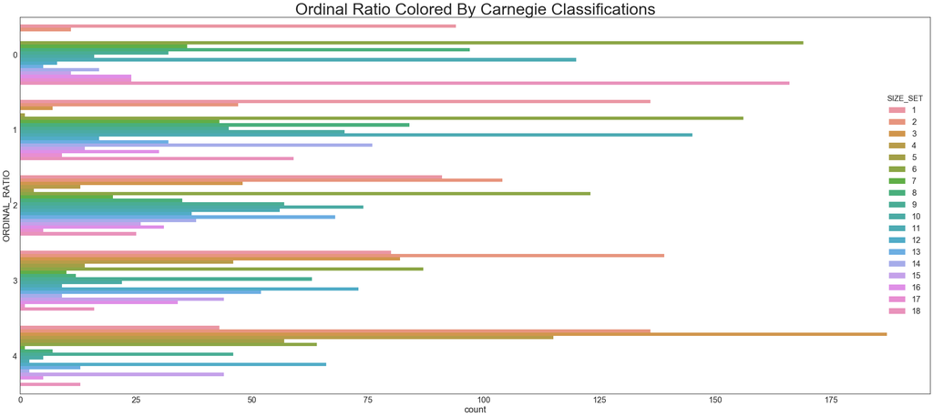

```python
'''
Plot Student-Employee Ratio Colored by Carnegie Classifications
'''
# Look at the distribution of NAICS school descriptions
sns.set(style="white", font_scale=2)
f, ax = plt.subplots(figsize=(40, 17))
plt.title('Ordinal Ratio Colored By Carnegie Classifications', fontsize=40)
# Dropped negative values in data set because they are uniformly distributed amongst ratios do not contribute to the analysis
sns.countplot(y='ORDINAL_RATIO', hue='SIZE_SET', data=df[df.SIZE_SET > 0])
```

This graph suggests that **higher Carnegie classifications** have lower student-employee ratios, which suggests better accommodation.

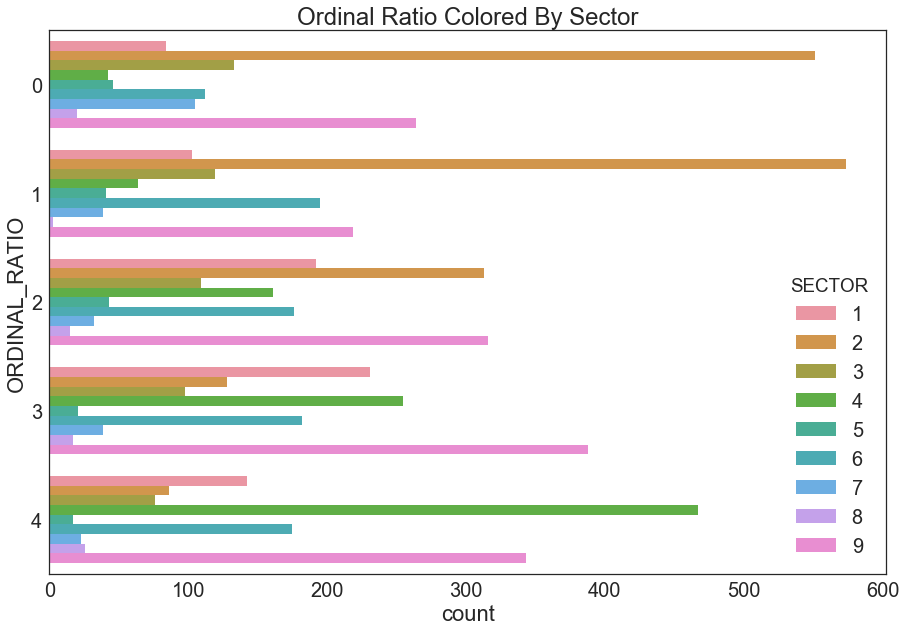

```python
'''
Plot Student-Employee Ratio Colored by Insitution Sector
'''
# Look at the distribution of NAICS school descriptions
sns.set(style="white", font_scale=2)
f, ax = plt.subplots(figsize=(15, 10))
plt.title('Ordinal Ratio Colored By Sector')
sns.countplot(y='ORDINAL_RATIO', hue='SECTOR', data=df)
```

This graph suggests that **lower sector values** have lower student-employee ratios, which suggests better accommodation. In particular, institution sector levels less than 4 appear to have better student-employee accomodation.

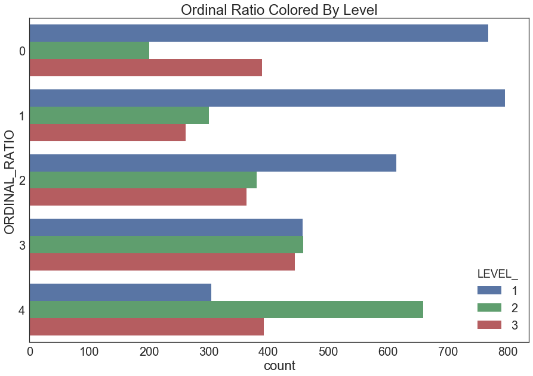

```python
'''
Plot Student-Employee Ratio Colored by Institution Level
'''
# Look at the distribution of NAICS school descriptions
sns.set(style="white", font_scale=2)
f, ax = plt.subplots(figsize=(15, 10))
plt.title('Ordinal Ratio Colored By Level')
sns.countplot(y='ORDINAL_RATIO', hue='LEVEL_', data=df)
```

This graph suggests that a **lower institution level** has lower student-employee ratios and are generally more accommodating. Primarily, institutions with level 1 have lower student-employee ratios than institutions with level 2.

# Summary of Insights & the Data-Driven Story

The original question is **which schools are most accommodating for students?**

While many of the insights drawn from exploratory analysis and PCA overlap, the overarching insight is that schools with **better accommodation** based on the student-employee ratio have:

- higher highest offers
- higher Carnegie Classification numbers
- lower institution sector numbers
- lower institution level numbers

Other insights:

- Most colleges, universities, and professional schools are accommodating. They have higher highest offers and lower institution levels, which are correlated to higher Carnegie Classifications and lower sector numbers. Schools with higher total dormitory capacity tend to have lower institution levels, which suggests that this school category also has higher enrollment and total dormitory capacity, which covers a different type of accommodation.

Answer to the original question:

- **Colleges, universities, and professional schools** are most accommodating based on the student-employee ratio and would most likely provide living accommodations in dormitories with more students enrolled full-time.